# ЗАНЯТИЕ 8. Scipy. Примеры статистики, z–статистика и p–value[1]

[1] ☝🙂 Данное занятие разработано на основе официального руководства Scipy [14] и русскоязычного источника [17].

## Цели занятия

Продолжение изучения функциональности, доступных методов и объектов статистики библиотеки `Scipy` – генерация случайных чисел и параметры формы распределения. Исследование принадлежности ряда значений к конкретному закону распределения (на основе параметров формы, куртозиса и др.). Построение диаграмм размах. Рассмотрение примеров описательной статистики из реального мира (z–статистика и p–значение).

## Порядок выполнения работы

### Генерация случайных чисел

Генерация случайных чисел (рядов величин случайного распределения) зависит от генераторов из модуля `numpy.random`.

Часто бывает необходимо сгенерировать ряд чисел, который при каждой новой перегенерации одинаков – например, мы его используем как опорный при сравнении с другим рядом чисел, чтобы сравнить на сколько схожа форма исследуемого распределения с тем, или иным законом распределения, чтобы далее определить какие статистические методы и подходы возможно применять к исследуемому ряду случайных величин.

Чтобы случайно сгенерированный опорный ряд чисел не менялся при каждом новом запуске кода и не отвлекал тем самым концентрацию аналитика данных (или в виду любой другой причины), мы можем сделать сгенерированный ряд чисел воспроизводимым.

Чтобы добиться воспроизводимости, необходимо явно указать генератор случайных чисел. В `NumPy` генератор является экземпляром класса `numpy.random.Generator`. Вот канонический (т.е. наиболее часто используемый) способ создания генератора:

```python
from numpy.random import default_rng
rng = default_rng()
```

Таким образом мы записали в переменную `rng` экземпляр генератора, который далее сможем использовать в `scipy`. Однако необходимо изначально «закрепить» сид (seed c англ. – семя[2]), и сделать это можно представленным ниже способом. Сид используется как начальное условие для генерации случайного числа. Т.е. некоторый стартовый шум. Чем он длиннее, тем лучше.

[2] ☝🙂 Т.е. сид – это, условно говоря, «что-то с определенным набором исходных признаков, которые будут воспроизведены». В данном случае речь про опорную комбинацию чисел, на базе которой генерируется случайная последовательность.

```python
#смените 1234 на что-то своё
rng = default_rng(1234)
```

#### Генерация по нормальному закону распределения

В примере ниже мы сгенерировали 5 случайных величин, распределенных по нормальному закону распределения, используя вызов «`norm.rvs(size=5, random_state=rng)`»:

```python
#для работы с нормальным распределением
from scipy.stats import norm

norm.rvs(size=5, random_state=rng)
```

```
array([-1.60383681,  0.06409991,  0.7408913 ,  0.15261919,  0.86374389])
```

где параметры:

- `size` – количество значений для генерации (сколько сгенерировать);
- `random_state` – целочисленное значение сида, или экземпляр класса генератора. В данном случае мы передали экземпляр генератора с указанным сидом.

Теперь данные генерируются на основе экземпляра генератора `rng`, в котором ранее был указан сид «`1234`», и форма их распределения всегда будет одинакова.

По умолчанию, т.е. если не указывать параметр `random_state`, используется `numpy.random.RandomState` генератор со случайным сидом (но `numpy.random.Generator` – более совершенный генератор). Если вас устраивает генератор по умолчанию, то вы можете установить только сид, а не менять генератор целиком:

```python
norm.rvs(size=5, random_state=1234)
```

```
array([ 0.47143516, -1.19097569,  1.43270697, -0.3126519 , -0.72058873])
```

Если вам нужно сгенерировать сид, то хорошим способом для этого является представленный ниже способ:

```python
from numpy.random import SeedSequence

print(SeedSequence().entropy)
```

```
244895680127195930623930452026677552409
```

В рамках данного занятия конкретное значение сида не является принципиальным. Можете установить сид на своё усмотрение или вовсе его не указывать.

Кроме генерации рядов с нормальным распределением, можно генерировать наборы случайных величин, с гамма распределением, или с любым другим типом распределения. Полный список которых можно найти в официальной документации `scipy` или `numpy`. Принцип такой же (как и при рассмотренном ранее вызове `norm.rvs()`), только может отличатся набор передаваемых параметров. Например, для гамма распределения требуется ещё указывать параметр формы. В коде ниже показано три примера генерации рядов с гамма распределением.

```python
from scipy.stats import gamma

a = 1.99  # форма
b = 1  # масштаб

rng = default_rng(seed=1234)

print(
    "1)Дважды вызовем gamma.rvs() из scipy.stats:\n",
    gamma.rvs(a=a, scale=b, size=3, random_state=rng),
    "не равно",
    gamma.rvs(a=a, scale=b, size=3, random_state=rng),
)
print("Так как сид - при каждом использовании меняется")

print("2)Вызов rng.gamma() из numpy.random:")
rng = default_rng(seed=1234)
print(rng.gamma(a, scale=b, size=3))
print(
    "Он равен первому запуску gamma.rvs из пункта 1, т.к. у него сид тоже 1234",
)

rng = default_rng(seed=1234)
print(
    "3)gamma.rvs со сдвигом loc=+5:\n",
    gamma.rvs(a=a, loc=5, scale=b, size=3, random_state=rng),
)
print("Значения равны первому запуску из п.1, но каждое увеличено на 5.")
```

```
1)Дважды вызовем gamma.rvs() из scipy.stats:
 [0.33106082 2.80495534 3.03563217] не равно [0.38916187 0.30440218 1.08075301]
Так как сид - при каждом использовании меняется
2)Вызов rng.gamma() из numpy.random:
[0.33106082 2.80495534 3.03563217]
Он равен первому запуску gamma.rvs из пункта 1, т.к. у него сид тоже 1234
3)gamma.rvs со сдвигом loc=+5:
 [5.33106082 7.80495534 8.03563217]
Значения равны первому запуску из п.1, но каждое увеличено на 5.
```

Представим комментарии для каждого из трех пунктов представленного выше примера (нумерация соответствует нумерации в коде):

1. Даже если вы указали сид, то он используется только как начальное условие.

На втором и далее запусках генератор на основе, казалось бы, этого же сида будет генерировать уже другие значения. Поэтому необходимо указывать сид каждый раз при необходимости при одном и том же действии получить одинаковые ряды случайных чисел.

Но такое бывает редко. Обычно указываете сид один раз, а далее получаете разные наборы данных на его основе. Когда нужно скопировать ряд чисел, то проще его действительно скопировать, чем «сбрасывать» генератор и устанавливать сид заново.

На основе однократно установленного сида, вы можете получить, например, 3 ряда значений, которые константны при каждом перезапуске кода и не равны друг другу.

1. Так как функционал генерации случайных значений из библиотеки `scipy` основан на использовании библиотеки `numpy`, то вы можете сгенерировать этот же ряд чисел, но сразу при помощи `numpy`[3].

[3] ☝🙂 Сравните, например, описание гамма генератора из `scipy` и из `numpy`, доступные соответственно по url: https://docs.scipy.org/doc/scipy/reference/generated/scipy.stats.gamma.html и https://numpy.org/doc/stable/reference/random/generated/numpy.random.Generator.gamma.html . Они почти идентичны.

Установив одинаковый сид и генератор, используя `scipy` и `numpy` методы генерации мы получим одинаковые значения.

1. У `scipy` по сравнению с `numpy` доступны некоторые дополнительные возможности. Например, в данном случае в п.3 примера представлено, что у метода генерации `scipy` нам доступен дополнительный параметр `loc`, который сдвигает все значения на требуемую величину.

При любой генерации последовательности случайных значений, необходимое количество значений указывается именно как именованный параметр, т.е., например – «`size=3`». Что в случае, например, при генерации с нормальным распределением выглядит следующим образом:

```python
norm.rvs(size=3)
```

```
array([-0.38509399, -1.41809613, -1.11892976])
```

Не подумайте, что написав «`norm.rvs(5)`» сгенерируется 5 чисел:

```python
norm.rvs(5)
```

```
4.494626496096593
```

В примере выше аргумент 5 без ключевого слова интерпретируется как первый возможный аргумент, чем является ключевое слово `loc` (сдвиг значений), принимаемое всеми непрерывными распределениями. Это подводит нас к теме следующего подраздела, где мы более детально рассмотрим передаваемые параметры в методы генерации рядов случайных чисел.

#### Сдвиг и масштабирование

Все непрерывные распределения принимают `loc` и `scale` в качестве ключевых параметров для настройки положения и масштаба распределения (дословно с англ.: `loc` – location, положение, или сдвиг, а `scale` – масштаб).

Значения по умолчанию `loc=0` и `scale=1`.

```python
import numpy as np
import scipy.stats as stats

x = norm.rvs(size=5)
x=np.sort(x) #сортируем по возрастанию
print('1)x:', x)

my_cdf = norm.pdf(x, loc=x.mean(), scale=x.std())
print('2)cdf для x:', my_cdf)

print('3)stats.describe(x):', stats.describe(x))
```

```
1)x: [-0.28261606  0.20786987  0.93076533  1.05109154  1.88505616]
2)cdf для x: [0.20158913 0.40765157 0.52167626 0.49600115 0.17052975]
3)stats.describe(x): DescribeResult(nobs=5, minmax=(-0.28261605628099606, 1.8850561621058326), mean=0.7584333705248865, variance=0.6928825239711739, skewness=0.07997415031319736, kurtosis=-1.1215898621016405)
```

где:

- `x.mean()` – вычисление среднего арифметического для выборки х;
- `x.std()` – вычисление стандартного отклонения.

В пункте 3 кода выше продемонстрировано использование метода `stats.describe()` библиотеки `scipy`, который выводит статистику по нашему распределению. Три последних значения – это разброс (дисперсия), асимметрия и коэффициент эксцесса (`varience`, `skewness` и `kurtosis` соответственно).

#### Генерация по показательному (экспоненциальному) закону распределения

Чтобы дополнительно проиллюстрировать масштабирование, рассмотрим подробнее кумулятивную функцию `cdf` и функцию плотности вероятности `pdf` для экспоненциального (или показательного) распределения. Функция плотности вероятности[4] для экспоненциального распределения вычисляется по формуле 9.

[4] ☝🙂 На русской версии ресурса «Википедия» подробно описаны функции и параметры для многих типов распределений. Например, по url https://ru.wikipedia.org/wiki/Нормальное_распределение вы сможете ознакомится с функцией нормального распределения и его функцией плотности вероятности `pdf.`

| $$F(x) = \left\{ \begin{matrix} e^{- \lambda x},\ \ x \geq 0 \\ \ 0,\ \ \ \ \ \ \ x < 0 \\ \end{matrix} \right.\ $$ | (9) |
| --- | --- |

где:

- F(x)– значение вероятности для значения х;
- Вместо параметра λ (`lambda`) указывается масштаб «`scale=1/lambda`». Т.к. масштаб по умолчанию равен 1, то, если не указывать масштаб[5], то и λ равна единице.

[5] ☝🙂 Взято из документации scipy, которую вы можете изучить по url: https://docs.scipy.org/doc/scipy/reference/generated/scipy.stats.expon.html .

Кумулятивная функция распределения (`cdf`) показывает вероятность того, что целевое значение меньше указанного значения либо равно ему. Она доступна только для количественных целевых значений.

Функция плотности вероятности (`pdf`) показывает распределение целевых значений. Для количественных целевых значений она позволяет определять вероятность того, что они находятся в данной области.

Поэкспериментируйте со сменой положения (`loc)` и масштаба (`scale)` в коде ниже.

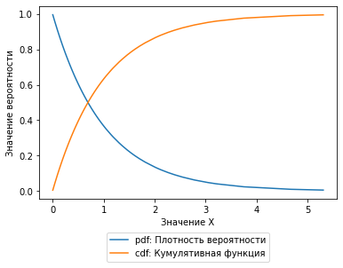

```python
import matplotlib.pyplot as plt  # библиотека для графиков
from scipy.stats import expon

rng = default_rng(seed=1234)

scale = 1  # масштаб
loc = 0  # положение

xvalues = expon.rvs(size=100, loc=loc, scale=scale, random_state=rng)
xvalues = np.sort(xvalues)  # сортируем по возрастанию

pdf = stats.expon.pdf(xvalues, loc, scale)  # функция плотности вероятности
cdf = stats.expon.cdf(xvalues, loc, scale)  # кумулятивная функция

plt.xlabel("Значение X")
plt.ylabel("Значение вероятности")
plt.plot(xvalues, pdf, label="pdf: Плотность вероятности")
plt.plot(xvalues, cdf, label="cdf: Кумулятивная функция")
plt.legend(loc="upper center", bbox_to_anchor=(0.5, -0.15))  # показать названия
plt.show()  # показать график
```

Рис. 1. Вывод графика `CDF` для экспоненциального распределения

#### Генерация по равномерному закону распределения

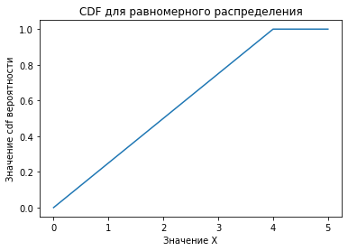

```python
from scipy.stats import uniform

scale = 4
loc = 0

xvalues = [0, 1, 2, 3, 4, 5]
cdf = uniform.cdf(xvalues, loc, scale)

plt.title("CDF для равномерного распределения")
plt.xlabel("Значение X")
plt.ylabel("Значение cdf вероятности")
plt.plot(xvalues, cdf)
```

Рис. 2. Вывод графика `CDF` для равномерного распределения

Рекомендуется устанавливать `loc` и `scale` параметры в явном виде, путем передачи ключевых слов и их значений, а не просто перечислять значение аргументов по порядку («`имя_параметра=значение`», а не «`значение`»).

Так же вы можете создать экземпляр класса распределения, а потом его использовать. Например, представленным ниже способом:

```
[ 0  1  2  3  4  5  6  7  8  9 10]
[0.1 0.1 0.1 0.1 0.1 0.1 0.1 0.1 0.1 0.1 0.1]
У равномерного распределения pdf равно для всех значений, т.к. они равновероятны.
```

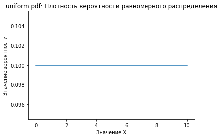

```python
xvalues = range(0, 11)
xvalues = np.sort(xvalues)  # сортировка по возрастанию
print(xvalues)

rv = uniform(loc=xvalues.min(), scale=xvalues.max())
my_pdf = rv.pdf(xvalues)
print(my_pdf)
print("У равномерного распределения pdf равно для всех значений, т.к. они равновероятны.")

plt.title("uniform.pdf: Плотность вероятности равномерного распределения")
plt.xlabel("Значение X")
plt.ylabel("Значение вероятности")
plt.plot(xvalues, my_pdf)
```

Рис. 3. Вывод плотности вероятности (`pdf`) для равномерного распределения

В примере выше в переменную `rv` мы записали сконфигурированное распределение. Такое действие в `scipy` называется «заморозкой» распределения. Используя «замороженное» распределение, мы можем передавать ему только данные, а все остальные параметры останутся такими, как было указано при «заморозке». В данном примере вызов «`rv.pdf(xvalues)`» по факту выполнит «`uniform.pdf(xvalues,loc=xvalues.min(),scale=xvalues.max())`».

#### Генерация по гамма закону распределения. Дополнительные параметры формы

В то время как общая непрерывная случайная величина может быть сдвинута и масштабируется при помощи `loc` и `scale` параметров, для некоторых других типов распределения могут существовать другие параметры формы. Например, гамма–распределение имеет следующую функцию плотности (формула 10 – полный вариант[6], формула 11 – упрощенный):

[6] ☝🙂 Подробнее: https://docs.scipy.org/doc/scipy/reference/generated/scipy.stats.gamma.html .

| $$F(x,\alpha,\beta) = \frac{{\beta^{\alpha}x}^{\alpha - 1}}{\Gamma(a)}\mathbb{e}^{- \beta x}$$ | (10) |
| --- | --- |
| $$F(x,a) = \frac{x^{a - 1}}{\Gamma(a)}\mathbb{e}^{- x}$$ | (11) |

Формулы 10 и 11 справедливы для *x* ≥ 0. При *x* < 0 плотность вероятности равна нулю. *Γ*(*a*) – это гамма-функция.

Как видно в формулах 10 и 11 требуется указывать как минимум ещё один параметр, кроме уже рассмотренных параметров `loc` и `scale`, а именно – параметр формы *a* (альфа). Обратите внимание, что вы дополнительно так же можете указать и параметр *β*, задав для ключевого слова `scale` значение «1/β».

Реализуем сказанное выше, а именно зададим параметры формы *a* и *β* гамма-распределения (код ниже). Поэкспериментируйте с параметрами формы, и сравните их с готовыми графиками плотности вероятности гамма–распределения, доступными в сети Интернет, например, по url: https://ru.wikipedia.org/wiki/Гамма-распределение (Рис. 5, где k – это `а`, а θ – это `scale`[7]).

[7] ☝🙂 В разных источниках отличаются как обозначения, так и варианты представления формул. Рисунок намеренно не адаптирован – чтобы читатель данного материала сам учился адаптироваться к разнородности материала. Это важный навык для аналитика данных. Вернитесь так же к уже рассмотренным графикам других распределений и сравните их с материалами из сети Интернет. Например, в ресурсе «Википедия» много материала с полезными графиками.

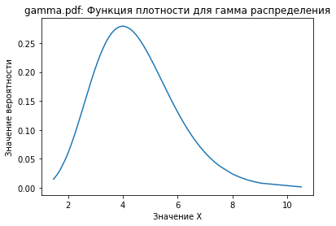

```python
from scipy.stats import gamma

a = 9.0
beta = 2.0
scale = 1 / beta

xvalues = gamma.rvs(size=300, a=a, scale=scale)
xvalues = np.sort(xvalues)  # сортируем по возрастанию

pdf = gamma.pdf(xvalues, a, loc=0, scale=scale)

plt.title("gamma.pdf: Функция плотности для гамма распределения")
plt.xlabel("Значение X")
plt.ylabel("Значение вероятности")

plt.plot(xvalues, pdf)
```

Рис. 4. Вывод плотности вероятности (`pdf`) для гамма распределения

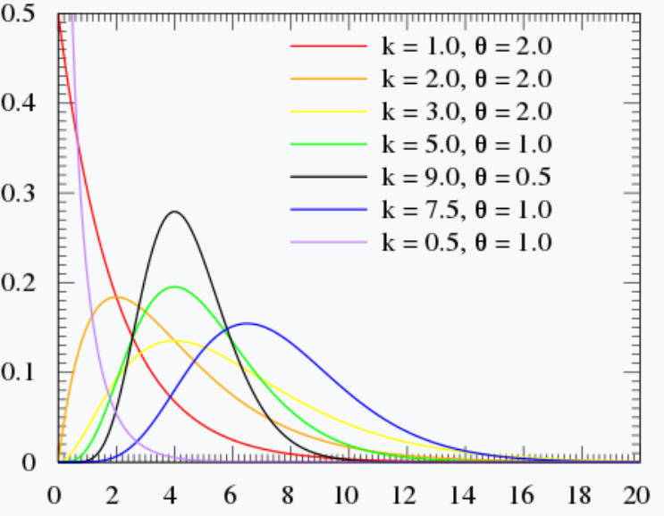

Рис. 5. `PDF` для гамма распределения (с разными значениями параметров)

Когда альфа – целое число, то такое гамма распределение так же называется распределением Эрланга порядка альфа, а когда a = 1 – то такое гамма распределение сводится (преобразуется) к экспоненциальному (показательному) распределению с параметром β (напоминаем, в интерпретации рисунка из сети Интернет (Рис. 5) – вместо а и β понимается k и θ соответственно; т.е. разные обозначения одного и того же, и при этом в `scipy` вы задаете β через `«scale=1/β» и` θ лишь отражает β, но не является им).

При этом во втором случае (когда гамма распределение сводится к показательному распределению), то наш β параметр будет является λ параметром формулы 9 (формула плотности вероятности показательного распределения)[8].

[8] ☝🙂 Т.е., к сожалению, снова некоторая путаница обозначений.

Говоря более конкретно и более простым языком, приведем пример, на Рис. 5 график с k = 1 – это распределение Эрланга 1 порядка и показательное распределение с λ = 0.5 одновременно (`a=1`, `beta=0.5`, `scale=1/beta`).

Сравните «`stats.expon.pdf(xvalues, loc=0, scale=1/0.5)`» с «`gamma.pdf(xvalues,a=1,loc=0,scale=(1/0.5))`». Сделать это можно при помощи кода, который далее будет представлен.

Графики совпадут и будут как на рисунке после кода (Рис. 6). Обратите внимание, что в коде специально сдвинут один график относительно другого на 0.1 по горизонтальной оси и на 0.01 – по вертикальной. Сдвиг добавлен только с целью чтобы можно было увидеть оба графика, иначе один бы перекрыл полностью другой, т.к. они полностью совпадают, так как гамма распределение полностью «свелось» к экспоненциальному.

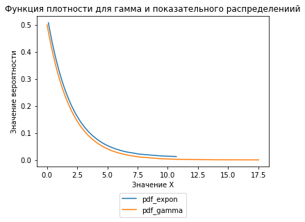

```python
a = 1
beta = 0.5
scale = 1 / beta

rng = default_rng(seed=1234)
xvalues_gamma = gamma.rvs(size=300, a=a, scale=scale, random_state=rng)
xvalues_gamma = np.sort(xvalues_gamma)  # сортируем по возрастанию

pdf_gamma = gamma.pdf(xvalues_gamma, a, loc=0, scale=scale)

plt.title("Функция плотности для гамма и показательного распределениий")

scale = 2  # масштаб
loc = 0  # положение

rng = default_rng(seed=1234)
xvalues_expon = expon.rvs(size=100, loc=loc, scale=scale, random_state=rng)
xvalues_expon = np.sort(xvalues_expon)  # сортируем по возрастанию

pdf_expon = stats.expon.pdf(xvalues_expon, loc, scale)  # функция плотности вероятности

plt.xlabel("Значение X")
plt.ylabel("Значение вероятности")
plt.plot(xvalues_expon+0.1, pdf_expon+0.01, label="pdf_expon")
plt.plot(xvalues_gamma, pdf_gamma, label="pdf_gamma")
plt.legend(loc="upper center", bbox_to_anchor=(0.5, -0.15))  # показать названия
plt.show()  # показать график
```

Рис. 6. `PDF` гамма распределения, сведенного к показательному распределению

### Отсутствие явно указанных параметров формы – проблема

В примере ниже продемонстрировано наглядное влияние отсутствия указания сдвига и масштаба в явном виде (так же актуально и для иных параметров формы).

```
стандартное отклонение) 1.1672213991949976
разброс (дисперсия) 1.362405794738728
среднее 0.0644679642998933
медиана 0.30579419811826114
```

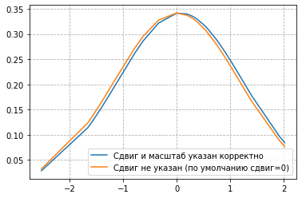

```python
x_rvs = norm.rvs(size=30)
x_rvs = np.sort(x_rvs)
print('стандартное отклонение)', x_rvs.std())
print('разброс (дисперсия)',x_rvs.var())
print('среднее',x_rvs.mean())
print('медиана',np.median(x_rvs))

#График PDF
my_cdf = norm.pdf(x_rvs, loc=x_rvs.mean(), scale=x_rvs.std())
plt.plot(x_rvs, my_cdf, label='Сдвиг и масштаб указан корректно')
my_cdf = norm.pdf(x_rvs, scale=x_rvs.std())
plt.plot(x_rvs, my_cdf, label='Сдвиг не указан (по умолчанию сдвиг=0)')
plt.legend()
plt.grid(linestyle='--') #добавить пунктирную сетку
plt.show() #показать график
```

Рис. 7. Отсутствие явного указания параметров формы и положения

Как видно на рисунке выше (Рис. 7) графики функций плотности различаются, хотя построены на одном и том же ряде значений. Это так, потому что без указания параметров формы и сдвига, используются значения по умолчанию и строится график для них (т.е. со стандартным сдвигом и масштабом).

Обратите внимание, что ваши данные используются лишь для задания диапазона значений по осям, а форма графика будет идеальной, потому что рассчитывается по формуле той функции распределения, которую используете.

Как обойти данное ограничение, если заранее неизвестно по какому закону распределен ваш ряд значений? – Рассмотрим далее.

### Анализ принадлежности ряда значений к конкретному закону распределения

В примере ниже продемонстрирована последовательность действий как один из возможных подходов определения закона распределения конкретного закона распределения.

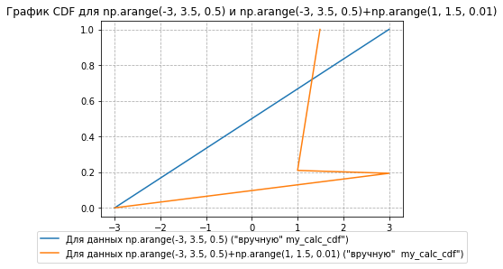

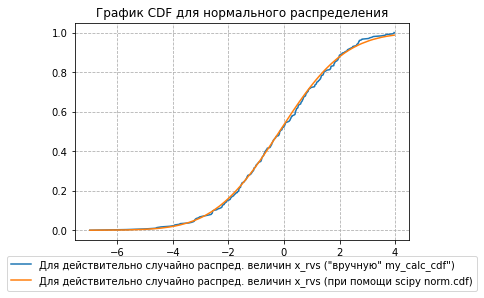

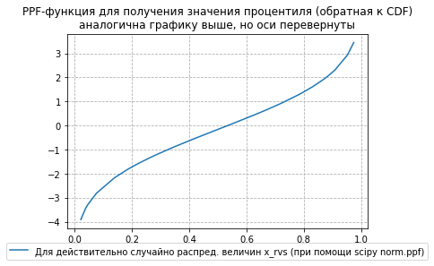

```python
def my_calc_cdf(x):
    x = np.sort(x)
    my_cdf = (
        1.0 * np.arange(len(x)) / (len(x) - 1)
    )  # calculate the proportional values of samples
    # print (x)
    # print (my_cdf)
    return my_cdf

x = np.arange(-3, 3.5, 0.5)
x_rvs = norm.rvs(size=300, loc=x.mean(), scale=x.std())
x_rvs = np.sort(x_rvs)

# График CDF для np.arange(-3, 3.5, 0.5) и np.arange(-3, 3.5, 0.5)+np.arange(1, 1.5, 0.01)
my_cdf = my_calc_cdf(x)
plt.plot(x, my_cdf, label='Для данных np.arange(-3, 3.5, 0.5) ("вручную" my_calc_cdf")')

x = np.append(x, np.arange(1, 1.5, 0.01))  # увееличим колличество значений.
my_cdf = my_calc_cdf(x)
plt.plot(x,my_cdf, label='Для данных np.arange(-3, 3.5, 0.5)+np.arange(1, 1.5, 0.01) ("вручную"  my_calc_cdf")',)

plt.legend(loc="upper center", bbox_to_anchor=(0.5, -0.05))
plt.grid(linestyle="--")  # добавить пунктирную сетку
plt.title("График CDF для np.arange(-3, 3.5, 0.5) и np.arange(-3, 3.5, 0.5)+np.arange(1, 1.5, 0.01)")
plt.show()  # показать график

# График CDF для нормального распределения
my_cdf = my_calc_cdf(x_rvs)
plt.plot(x_rvs, my_cdf, label='Для действительно случайно распред. величин x_rvs ("вручную" my_calc_cdf")',)

my_cdf = norm.cdf(x_rvs, loc=x_rvs.mean(), scale=x_rvs.std())
plt.plot(x_rvs, my_cdf, label="Для действительно случайно распред. величин x_rvs (при помощи scipy norm.cdf)",)

plt.legend(loc="upper center", bbox_to_anchor=(0.5, -0.05))
plt.grid(linestyle="--")  # добавить пунктирную сетку
plt.title("График CDF для нормального распределения")
plt.show()  # показать график

# График PPF (ОБРАТНЫЙ К CDF)
percentel_arr = np.linspace(0, 100, len(x_rvs))
my_ppf = norm.ppf(x_rvs, loc=x_rvs.mean(), scale=x_rvs.std())
plt.plot(x_rvs, my_ppf, label="Для действительно случайно распред. величин x_rvs (при помощи scipy norm.ppf)", )
plt.legend(loc="upper center", bbox_to_anchor=(0.5, -0.05))
plt.grid(linestyle="--")  # добавить пунктирную сетку
plt.title("PPF-функция для получения значения процентиля (обратная к CDF)\nаналогична графику выше, но оси перевернуты")
plt.show()  # показать график
```

где соответственно:

- Рис. 8. `CDF` для рядов, для которых неизвестен (условно) закон распределения
- Рис. 9. `CDF` для нормального закона распределения
- Рис. 10. `PPF` для нормального закона распределения

Имея некоторые данные, вы всегда можете «вручную» построить, например, график `cdf` (или по сути график процентилей, первый график из вывода кода или Рис. 8) при помощи своей собственной функции `my_calc_cdf()`, которая просто сгенерирует процентили с некоторым константным шагом в количестве равном количеству ваших значений.

Это просто и правильно, однако данные необходимо предварительно отсортировать, например, при помощи `np.sort()`.

После получения `cdf` для наших данных нам необходимо сравнить, его с `cdf` того закона распределения, с которым установку сходства мы предполагаем. Например, в данном случае выведем `cdf` нормального закона (второй выведенный примером рисунок, или Рис. 9) и сравним его с `CDF` того ряда, анализ которого нам интересен (первый выведенный кодом рисунок, или Рис. 8).

Как видим, графики `cdf` для обоих рядов из первого выведенного примером рисунка (Рис. 8) не похожи на графики из второго (Рис. 9). Делаем вывод, что изучаемые ряды не имеют `cdf` схожую с `cdf` нормального закона, а значит, возможно, в целом не имеют с нормальным законом распределения ничего общего. Возможно было проще сравнить графики распределения с целью получения этого же вывода, но мы намеренно поступили сложным путём.

Чтобы вспомнить и закрепить что такое `ppf` (функция получения процентилей) и как она работает, в примере выше так же выводится третий график (Рис. 10), представляющий полный аналог второго графика из вывода данного пример (Рис. 9), но оси инвертированы. Это так, потому что `ppf` является обратной по отношению к `cdf` функцией.

### Куртозис и сдвиг (моменты, и прочие понятия статистики)

В `scipy` доступны функции и методы для получения и многих других, кроме уже рассмотренных, параметров статистки. В примере ниже представлено вычисление куртозиса (острота пика в середине) и перекоса (значений относительно медианы).

```
среднее  0.1460417720912563
разброс (дисперсия)  0.8141958943422879 или 0.8141958943422878
перекос  -0.015703832031889967
куртозис (острота пика) -0.44151933458656734
```

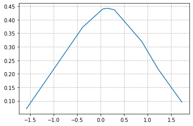

```python
from scipy.stats import kurtosis, skew

x = norm.rvs(size=10)
x = np.sort(x)

my_cdf = norm.pdf(x,loc=x.mean(), scale=x.std())
kurt=kurtosis(x) #куртозис, или коэф. эксцеса (острота пика)
skew=skew(x) # перекос
mean, var= norm.stats(loc=x.mean(), scale=x.std(), moments='mv')
print('среднее ', mean)
print('разброс (дисперсия) ',var,'или', x.var())
print('перекос ',skew)
print('куртозис (острота пика)',kurt)

plt.plot(x, my_cdf)
plt.grid(linestyle='--') #добавить пунктирную сетку
plt.show() #показать график
```

### Диаграмма размаха

Графики `cdf`, `pdf` – и другие просты (строятся по всего по двум рядам значений – значениям случайных величин и, по соответствующим им значениям функции, например, `pdf`), но не компактны, поэтому в описательной статистике очень часто используется построение диаграмм размаха («ящик с усами» – box-and-whiskers diagram или просто box plot – на англ. языке).

Диаграммы размаха в удобной форме показывают медиану (или, если нужно, среднее), нижний и верхний квартили, минимальное и максимальное значение выборки и выбросы. Расстояния между различными частями ящика так же позволяют определить степень разброса (дисперсии) и асимметрии данных.

Несколько таких «ящиков» можно нарисовать бок о бок, чтобы визуально сравнивать одно распределение с другим; их можно располагать как горизонтально, так и вертикально.

Подробно изучить про компоненты диаграммы размаха вы можете по url: https://towardsdatascience.com/understanding-boxplots-5e2df7bcbd51 (но основные положения представлены графически на рисунке ниже – Рис. 12), а про все её параметры – в документации той библиотеки, при помощи которой вы планируете их строить.

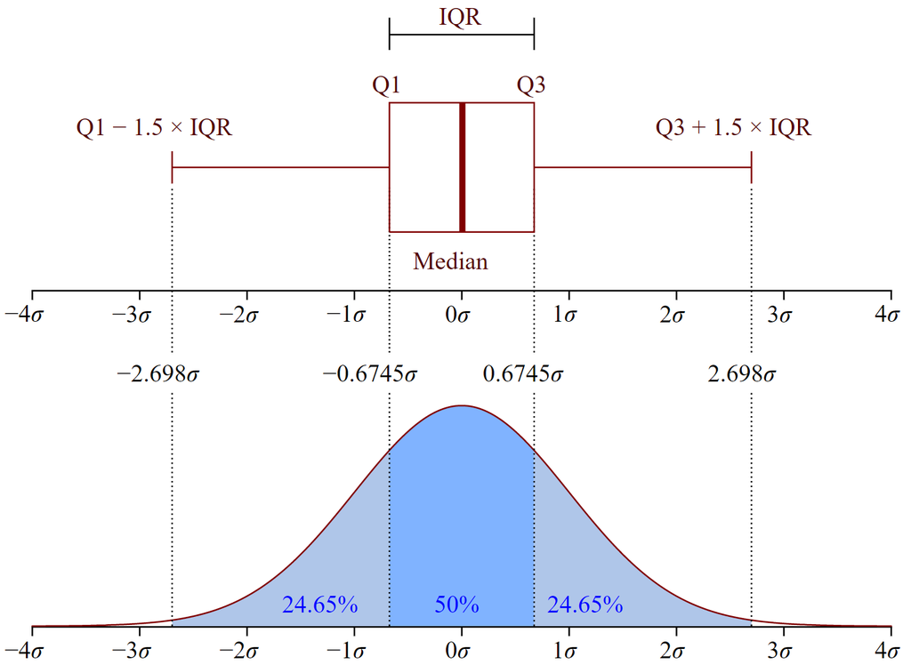

Рис. 12. Графический смысл диаграммы размаха на примере `pdf`

На Рис. 12 σ (сигма) – это среднеквадратичною отклонение, а Q1 и Q3 – первый и третий квартили.

Далее будет представлен пример вывода диаграммы размаха поверх функции плотности вероятности для ряда с нормальным распределением. Попробуйте, используя данный пример закрепить знания, уже полученные на занятиях по статистике – в этом вам поможет текстовый вывод данного примера (значение медианы, процентилей и др.). Единственное, что не было рассмотрено, это IQR.

IQR (с англ. interquartile range) – это межквартальный диапазон. Он определяется как разница между 75-м и 25-м процентилями данных. IQR является примером усеченного оценщика[9], определяемого как 25% усеченный диапазон, который повышает точность статистики набора данных за счет снижения вклада, отдаленных точек. Величина IQR определяет размер прямоугольника диаграммы размаха (в примере ниже – ширину).

[9] ☝🙂 В статистике усеченный оценщик — это оценщик, полученный из другого оценщика путем исключения некоторых экстремальных значений (выбросов) с целью повышения степени истинности статистики.

```
стандартное отклонение 1.072979870171188
размах (дисперсия) 1.151285801792579
среднее арифметическое 0.09502397604619701
медиана 0.023263434562540677
iqr 1.5845792823616374
25ый процентиль -0.7064941387274283
75ый процентиль 0.878085143634209
25ый процентиль + 1.5*IQR -3.083363062269884
75ый процентиль - 1.5*IQR -1.4987837799082468
"Интеграл pdf (должен стремится к 1, если все ок)" 0.9849200218098398
```

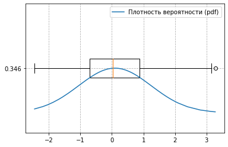

```python
from scipy.stats import iqr

x_rvs = norm.rvs(size=200)
x_rvs = np.sort(x_rvs)

my_pdf = norm.pdf(x_rvs, loc=x_rvs.mean(), scale=x_rvs.var())

print("стандартное отклонение", x_rvs.std())
print("размах (дисперсия)", x_rvs.var())
print("среднее арифметическое", x_rvs.mean())
print("медиана", np.median(x_rvs))
iqr = iqr(x_rvs)
print("iqr", iqr)
print("25ый процентиль", np.percentile(x_rvs, 25))
print("75ый процентиль", np.percentile(x_rvs, 75))
print('25ый процентиль + 1.5*IQR', np.percentile(x_rvs, 25) - 1.5 * iqr)
print('75ый процентиль - 1.5*IQR', np.percentile(x_rvs, 75) - 1.5 * iqr)
print('"Интеграл pdf (должен стремится к 1, если все ок)"', np.trapz(my_pdf, x_rvs))

# График PDF
plt.boxplot(x_rvs,vert=False, positions=[my_pdf.max().round(3),],)
plt.plot(x_rvs, my_pdf, label="Плотность вероятности (pdf)")
plt.legend()
plt.grid(linestyle="--")  # добавить пунктирную сетку

plt.show()  # показать график
```

Рис. 13. Диаграмма размаха на графике плотности вероятности

«Усы ящика» (длины горизонтальных линий слева и справа от прямоугольника) по умолчанию равны значению IQR*1,5. Т.е. сам IQR занимает 25% всего диапазона вправо и влево от середины (медианы – она отмечена чертой в центре прямоугольника, суммарно IQR занимает 50%), а усы занимают почти всю оставшуюся часть значений.

Любые точки данных, которые попадают «внутрь усов», называются мягкими выбросами. Точки, которые выходят за пределы «усов», называются экстремальными выбросами (и от них обычно избавляются).

### Примеры статистики из жизни[10]

[10] ☝🙂 Представленный в текущем разделе материал взят из русскоязычного источника: https://habr.com/ru/post/557424/. Выражаем его автору (Семёну Лукашевскому) большую благодарность как за материал, так и за согласие на его использование в данной книге. Материал представлен практически в оригинальном виде – с минимальными изменениями, и не распространяется с целью получения прибыли (в коммерческих целях).

#### Пример с временем доставки

Рассмотрим реальный пример из жизни: статистика времени доставки пиццы. Сперва произведем все импорты и настройки:

```python
import matplotlib.pyplot as plt
import numpy as np
import seaborn as sns  # statistical data visualization
from scipy import stats

sns.set()
from pylab import rcParams

rcParams["figure.figsize"] = 10, 6 # установка размеров графиков
%config InlineBackend.figure_format = 'svg'
np.random.seed(42)  # начальные условия для генератора случайных чисел
```

Теперь давайте представим, что в течение года мы заказываем пиццу на дом, при этом мы каждый раз смотрим на настенные стрелочные часы, отмечая время, которое проходит между заказом и доставкой, целым количеством минут. Тогда накопленные за год данные о доставке пиццы могли бы выглядеть так:

```python
norm_rv = stats.norm(
    loc=30, scale=5
)  # генерируем норм расп значения возле 30 плюс минус 5
samples = np.trunc(norm_rv.rvs(365))
samples[:30]
```

```
array([32., 29., 33., 37., 28., 28., 37., 33., 27., 32., 27., 27., 31.,
       20., 21., 27., 24., 31., 25., 22., 37., 28., 30., 22., 27., 30.,
       24., 31., 26., 28.])
```

Теперь выясним среднее время доставки пиццы и его среднеквадратическое отклонение:

```python
samples.mean(), samples.std()
```

```
(29.52054794520548, 4.77410133275075)
```

Можно сказать, что время доставки пиццы занимает около 30±5 минут. Посмотрим на то, как распределены данные:

```python
sns.histplot(x=samples, discrete=True);
```

[figure not shown]

Рис. 14. Распределение данных

Глядя на такой график (Рис. 14), мы вполне можем допустить, что время доставки пиццы имеет нормальный закон распределения с параметрами `mu=30` (среднее) и `sigma=5` (среднеквадратичное отклонение).

Посмотрим схожесть полученного распределения так же и с гамма, бета и треугольным законом распределения:

```python
norm_rv = stats.norm(loc=30, scale=5)
beta_rv = stats.beta(a=5, b=5, loc=14, scale=32)
gamma_rv = stats.gamma(a=20, loc=7, scale=1.2)
tri_rv = stats.triang(c=0.5, loc=17, scale=26)

x = np.linspace(10, 50, 300)

sns.lineplot(x=x, y=norm_rv.pdf(x), color="r", label="norm")
sns.lineplot(x=x, y=beta_rv.pdf(x), color="g", label="beta")
sns.lineplot(x=x, y=gamma_rv.pdf(x), color="k", label="gamma")
sns.lineplot(x=x, y=tri_rv.pdf(x), color="b", label="triang")

sns.histplot(x=samples, discrete=True, stat="probability", alpha=0.2);
```

[figure not shown]

Рис. 15. Распределение данных в сравнении с разными типами распределения

К какому конкретно типу распределения относится время доставки пиццы из множества всевозможных?

Доставкой пиццы занимается человек, а сам процесс доставки сопровождается множеством случайных событий, которые могут произойти на его пути.

Конечно, мы можем придумывать очень много таких событий, вплоть до самых невероятных. Тем не менее, для нас важно, чтобы эти события описывались такими переменными, значения которых равновероятны, т.е. распределены по равномерному закону.

В качестве примера, можно придумать переменную `X1`, которая будет описывать время ожидания зеленого света светофора на перекрестке. Если это время заключено в промежутке от нуля до четырех минут, то сегодня это время может составлять:

```python
unif_rv = stats.uniform(loc=0, scale=4)
unif_rv.rvs()
```

```
0.8943833540778106
```

А завтра, послезавтра и послепослезавтра это время может быть равно:

```python
unif_rv.rvs(size=3)
```

```
array([3.85289016, 0.0486179 , 3.87951531])
```

Теперь представим, что таких переменных 15 и значение каждой из них вносит свой вклад в общее время доставки, потому что эти события могут складываться.

Если мы придумали всего 15 случайных переменных: X1, X2, …, X15, то можно сказать, что общее время доставки является их суммой и тоже является случайной величиной, которую можно обозначить буквой Y (формула 12):

| $$Y = X_{1} + X_{2} + \ldots + X_{15} = \sum_{i = 1}^{15}X_{i}$$ | (12) |
| --- | --- |

В коде ниже мы получим 10 тысяч сумм, каждая из которых является суммой всех 15 равномерно распределенных (`unif_rv`) случайных величин:

```python
Y_samples = [unif_rv.rvs(size=15).sum() for i in range(10000)]
sns.histplot(x=Y_samples);
```

[figure not shown]

Рис. 16. Распределение 10 тысяч сумм 15-и случайных величин

Распределение суммы случайных переменных стремится к нормальному распределению при увеличении количества слагаемых в этой сумме.

Конечно, пример с доставкой пиццы не совсем корректен для демонстрации предельной теоремы, потому что все события, которые мы придумали, носят условный характер: это означает, что они могут входить в сумму в самых разных комбинациях. Например, сегодня время доставки задавалось, как в формуле 13, а завтра это время может задаваться как в формуле 14:

| $$Y = X_{3} + X_{5} + X_{7} + X_{11}$$ | (13) |
| --- | --- |
| $$Y = {X_{1} + X}_{3} + X_{9} + X_{10} + X_{13} + X_{15}$$ | (14) |

Будет ли теперь Y распределена по нормальному закону?

Учитывая, что сумма нормально распределенных величин тоже имеет нормальное распределение, то можно дать утвердительный ответ. Именно поэтому, когда мы взглянули на распределение 365–и значений времени доставки, мы практически сразу решили, что перед нами нормальное распределение, даже несмотря на то что оно вовсе не похоже на идеальный «колокол».

#### Z–значения

Допустим, по прошествии года у нас появился новый сосед и он так же, как и мы, решил ежедневно заказывать пиццу. И вот по прошествии трех дней мы наблюдаем, как этот сосед обвиняет доставщика в слишком долгом ожидании заказа. Мы решаем поддержать доставщика и говорим, что в среднем время доставки занимает 30±5 минут, на что наш сосед отвечает, что все три раза он ждал больше 40 минут, а это определенно больше 35 минут.

Почему наш сосед так уверен в долгой доставке? И вообще, оправдана ли его уверенность? Очевидно он, как и некоторые люди, думает, что 30±5 минут означает, что доставка может длиться 27, 31, даже 35 минут, но никак не 23 или 38 минут. Однако, мы заказывали пиццу 365 раз и знаем, что доставка может длиться и 20 и даже 45 минут. А фраза 30+-5 минут, означает лишь то, что какая–то значительная часть доставок будет занимать от 25 до 35 минут.

Зная параметры распределения, мы даже можем смоделировать несколько тысяч доставок и прикинуть величину этой части:

```python
N = 5000
t_data = norm_rv.rvs(N)
t_data[(25 < t_data) & (t_data < 35)].size / N
```

```
0.7008
```

Где–то две трети значений укладываются в интервал от 25 до 35 минут. А сколько значений будет превосходить 40 минут? – Отфильтруем значения, и выведем дробную часть, сколько они занимают по отношению к общему числу значений:

```python
t_data[t_data > 40].size / N
```

```
0.0248
```

Оказывается, только чуть более двух процентов значений превышают 40 минут. Но ведь сосед заказывал пиццу три раза подряд и все три раза доставка длилась больше 40 минут. Может сосед оказался просто очень везучим, ведь вероятность трех таких долгих доставок чрезвычайно мала и равна 0.02 в третьей степени:

```python
0.02 ** 3
```

```
8.000000000000001e-06
```

Для решения подобных задач обычно пользуются Z–значениями.

Z–оценка, или стандартизированная оценка (на англ. z–score или standard score соответственно) – это мера относительного разброса наблюдаемого или измеренного значения, которая показывает, сколько стандартных отклонений составляет его разброс относительного среднего значения. Это безразмерный статистический показатель, используемый для сравнения значений разной размерности или с разными шкалами измерений.

Вычислить Z–значение можно по следующей формуле (формула 15):

| $$Z = \frac{y - \mu}{\sigma}$$ | (15) |
| --- | --- |

где: y – это время доставки, т.е. какое-то конкретное значение случайной переменной Y, которая имеет нормальное распределение, а *μ* и *σ* [11] – это математическое ожидание и среднеквадратическое отклонение соответственно, т.е. параметры распределения, и в нашем случае они равны 30 и 5 минут соответственно.

Давайте рассчитаем Z-значение для сорока минут (формула 16):

| $$Z = \frac{40 - 30}{5} = 2$$ | (16) |
| --- | --- |

В числителе мы вычислили на какую величину время доставки отличается от среднего времени доставки, а далее мы поделили это значение на стандартное отклонение времени доставки. Но как интерпретировать данный результат и зачем вообще использовать Z–значение? – Что бы объяснить это мы воспользуемся графиком:

```python
fig, ax = plt.subplots()
x = np.linspace(norm_rv.ppf(0.001), norm_rv.ppf(0.999), 200)
ax.vlines(40.5, 0, 0.1, color="k", lw=2)
sns.lineplot(x=x, y=norm_rv.pdf(x), color="r", lw=3)
sns.histplot(x=samples, stat="probability", discrete=True);
```

[figure not shown]

На данном графике (вывод примера выше, или Рис. 17) мы изобразили гистограмму наших данных `samples`, но теперь высота прямоугольников показывает не количество вхождений каждого значения в выборку, а вероятность их появления в выборке. Или, говоря конкретнее данный график отражает функцию распределения плотности вероятности, т.е. `pdf.`

Красной линией мы отрисовали «образцовую» функцию распределения плотности вероятности для значений времени доставки.

Выше мы пытались экспериментальным путем определить какую долю составляют значения времени больше 40 минут. И данный график должен натолкнуть нас на мысль о том, что есть два способа сделать это.

```python
np.random.seed(42)
N = 10000
values = np.trunc(norm_rv.rvs(N))

fig, ax = plt.subplots()
v_le_41 = np.histogram(values, np.arange(9.5, 41.5))
v_ge_40 = np.histogram(values, np.arange(40.5, 51.5))
ax.bar(np.arange(10, 41), v_le_41[0] / N, color="0.8")
ax.bar(np.arange(41, 51), v_ge_40[0] / N)
p = np.sum(v_ge_40[0] / N)
ax.set_title("P(Y>40min) = {:.3}".format(p))
ax.vlines(40.5, 0, 0.08, color="k", lw=1);
```

[figure not shown]

Рис. 18. Плотность вероятности для доставок, которые больше 40 минут

Второй путь – аналитический. Поскольку мы знаем, что значения доставки пиццы берутся из нормального распределения, то мы можем воспользоваться функцией распределения плотности вероятности нормального распределения.

Функция распределения плотности хороша тем, что площадь под ней всегда равна единице и если нас интересует вероятность того, что величина примет значение большее или меньшее указанного, то достаточно найти площадь под функцией, которая находится правее или левее этого значения. Например, вычислить и изобразить вероятность того, что время доставки будет длиться более 40 минут можно так:

```python
fig, ax = plt.subplots()

x = np.linspace(norm_rv.ppf(0.0001), norm_rv.ppf(0.9999), 300)
ax.plot(x, norm_rv.pdf(x))

ax.fill_between(x[x > 41], norm_rv.pdf(x[x > 41]), np.zeros(len(x[x > 41])))
p = 1 - norm_rv.cdf(41)
ax.set_title("P(Y>40min) = {:.3}".format(p))
ax.hlines(0, 10, 50, lw=1, color="k")
ax.vlines(41, 0, 0.08, color="k", lw=1);
```

[figure not shown]

Рис. 19. Плотность вероятности для доставок, которые больше 40 минут

Значения вероятности в первом и втором случае получились довольно близкими. Но необходимо отметить, что в первом случае мы использовали дискретную случайную величину, а во втором – непрерывную.

В первом случае мы считаем сколько раз доставка составляла более 40 минут, т.е. считали сколько доставок длились 41, 42, 43 и т.д. минут.

Во втором случае мы считаем сколько непрерывных величин оказалось правее значения 41.0.

Модуль `SciPy` позволяет создавать собственные распределения случайных величин, в руководстве к этой библиотеки есть пример это, в котором показано создание дискретно-нормального распределения. Но если задуматься, то наличие дискретных значений и использование непрерывных функций распределения, это своего рода – неизбежность, ведь подавляющее большинство измерений носит дискретный характер: рост, вес, доход и т.д. Так что далее по этому поводу больше не будет указываться замечаний.

#### Пример с ростом народов

Вернемся к Z–значениям, но пример с доставкой пока отложим на второй план и временно перейдем к новому примеру.

Итак, допустим мы оказались в Средиземье и каким–либо образом выяснили, что рост хоббитов и гномов в сантиметрах распределен как N (91; 8^2) и N (134; 6^2). Если рост Фродо равен 99 сантиметрам, а рост Гимли – 143 сантиметра, то как понять чей рост более типичен среди своих народов? Что бы выяснить это мы можем изобразить функцию распределения плотности вероятности для каждого народа с отмеченными значениями, а заодно определить долю тех, кто превышает эти значения:

```python
fig, ax = plt.subplots(nrows=1, ncols=2, figsize=(12, 5))

nrv_hobbit = stats.norm(91, 8)
nrv_gnome = stats.norm(134, 6)

for i, (func, h) in enumerate(zip((nrv_hobbit, nrv_gnome), (99, 143))):
    x = np.linspace(func.ppf(0.0001), func.ppf(0.9999), 300)
    ax[i].plot(x, func.pdf(x))
    ax[i].fill_between(x[x > h], func.pdf(x[x > h]), np.zeros(len(x[x > h])))
    p = 1 - func.cdf(h)
    ax[i].set_title("P(H > {} см) = {:.3}".format(h, p))
    ax[i].hlines(0, func.ppf(0.0001), func.ppf(0.9999), lw=1, color="k")
    ax[i].vlines(h, 0, func.pdf(h), color="k", lw=2)
    ax[i].set_ylim(0, 0.07)
fig.suptitle("Хобиты слева, гномы справа", fontsize=20);
```

[figure not shown]

Рис. 20. Рост двух народов (хобиты слева, гномы справа)

По этим графикам (вывод примера выше, Рис. 20) можно предположить, что рост Фродо несколько ближе к вершине распределения чем рост Гимли. А это значит, что вероятность встретить хоббита с таким же ростом как у Фродо несколько больше вероятности встретить гнома с ростом как у Гимли. Именно это и понимается под словом «типичность».

Выполнить сравнение типичности гораздо проще и нагляднее если воспользоваться Z–значениями (формулы 17–18 и код ниже):

| $$Z = \frac{99 - 91}{8} = 1$$ | (17) |
| --- | --- |
| $$Z = \frac{143 - 134}{6} = 1.5$$ | (18) |

```python
fig, ax = plt.subplots()
N_rv = stats.norm()
x = np.linspace(N_rv.ppf(0.0001), N_rv.ppf(0.9999), 300)
ax.plot(x, N_rv.pdf(x))
ax.hlines(0, -4, 4, lw=1, color="k")
ax.vlines(1, 0, 0.4, color="r", lw=2, label="Фродо")
ax.vlines(1.5, 0, 0.4, color="g", lw=2, label="Гимли")
ax.legend();
```

[figure not shown]

Рис. 21. Рост Фродо и Гимли

Огромным преимуществом Z–значений является то, что они стандартизированы (нормализованы)[12], т.е. преобразованы так, словно они взяты из стандартного нормального распределения N (0; 1) – именно поэтому два Z–значения нарисованы на фоне единственной кривой.

[12] ☝🙂 Стандартизованная случайная величина (или нормализованная) – это случайная величина, математическое ожидание которой равно нулю, а среднеквадратическое отклонение – единице. Или, если случайная величинах имеет математическое ожидание μ, а среднеквадратическое отклонение – σ, то соответствующая стандартизованная случайная величина имеет вид X<sub>стандартиз.</sub>=(Х - μ)/σ. Распределение стандартизованной случайной величины называют «стандартным распределением».

Однако, в общем случае, даже построение графиков вовсе не обязательно, потому что меньшие по модулю Z–значения обладают большей частотой появления. Одного предположения (формула 19) уже достаточно для того что бы понять, какое из значений находится ближе к вершине распределения и сделать соответствующие выводы:

| \|ZФродо\|<\|ZГимли\| | (19) |
| --- | --- |

Сравнение Z–значений нескольких величин из разных «нормальных» выборок с разными параметрами распределения возможно потому, что сами Z–значения измеряются в «сигмах», т.е. имеют размерность стандартного отклонения[13].

[13] ☝🙂 Это станет более очевидным, если еще раз взглянуть на знаменатель формулы Z–значения (формула 15).

Имеет смысл отметить, что с математически–строгой точки зрения вероятность получения какого–либо конкретного значения из непрерывного распределения стремится к нулю. В таких случаях, всегда говорят о вероятности попадания этого значения в заданный интервал. Поэтому, когда мы говорим, что Z–значение какой–либо величины позволяет оценить вероятность (частоту) ее появления (этой величины), то мы вовсе не выходим за границы здравого смысла.

В реальном мире мы никогда не работаем с действительно непрерывными величинами. Да, мы можем измерять рост в нанометрах, а время в микросекундах, но это все равно будут дискретные значения. Распределение дискретных величин может хорошо приближаться распределением величин непрерывных – и нам этого достаточно.

#### Пример с временем доставки (продолжение)

Теперь давайте снова вернемся к нашему соседу, который возмущен слишком долгой доставкой пиццы. Ранее мы вычислили Z–значение для 40 минут, и оно составило 2 (т.е. Z<sub>40мин</sub>=2, формула 16). Пока у нас нет опыта, достаточного для того, чтобы сразу понять – много это или мало, то лучше изображать эти значения графически:

```python
fig, ax = plt.subplots()
N_rv = stats.norm()
x = np.linspace(N_rv.ppf(0.0001), N_rv.ppf(0.9999), 300)
ax.plot(x, N_rv.pdf(x))
ax.hlines(0, -4, 4, lw=1, color="k")
ax.vlines(2, 0, 0.4, color="g", lw=2);
```

[figure not shown]

Рис. 22. Z<sub>40мин</sub>=2

Это значение находится справа от вершины на расстоянии 2σ (2 сигма, т.е. на расстоянии двух стандартных отклонений), что довольно много. Однако, сосед утверждает, что ждал пиццу больше сорока минут три дня подряд. Возможно, он и не вычислял среднее время ожидания своей пиццы, но три значения – это уже статистика.

Характеристики генеральной совокупности называют параметрами, а характеристики выборки – статистиками.

```python
sns.histplot(np.trunc(norm_rv.rvs(size=(N, 3))).mean(axis=1), bins=np.arange(19, 42));
```

[figure not shown]

Рис. 23. Количество тех или иных сроков доставки

Судя по графику из вывода примера выше (Рис. 23), получить среднее значение трех заказов большее 40 минут – практически нереально (точнее маловероятно на фоне общего числа других сроков доставки). Поэтому тут возможны два предположения:

- либо сосед врет;
- либо это обусловлено генеральной совокупностью, т.е. по какой–либо причине доставка и правда длится дольше обычного.

Вычисленное выше Z–значение для сорока минут (Z<sub>40мин</sub>=2), позволяет оценить долю (вероятность появления) значений больших сорока:

```python
1 - N_rv.cdf(2)
```

```
0.02275013194817921
```

Поэтому не удивительно, что вероятность получить среднее время трех доставок большее 40 минут очень мала:

```python
(1 - N_rv.cdf(2)) ** 3
```

```
1.1774751750476762e-05
```

Если каждое отдельное значение времени доставки мы можем оценить с помощью Z–значения, то для того, чтобы оценить вероятность среднего арифметического этих значений нам нужно воспользоваться Z–статистикой (формула 20):

| $Z = \frac{\overline{x} - \mu}{\frac{\sigma}{\sqrt{n}}}$ | (20) |
| --- | --- |

где: $\overline{x}$ – это среднее арифметическое значение нашей выборки, *μ* и *σ* – математическое ожидание и стандартное отклонение соответственно для генеральной совокупности, а n – размер выборки.

Предположим, что мы сделали три заказа и среднее (арифметическое) значение оказалось равным 35 минутам, тогда Z-статистика будет вычисляться так (формула 21):

| $Z = \frac{35 - 30}{\frac{5}{\sqrt{3}}}$ | (21) |
| --- | --- |

Z–статистика, как и Z–значение является стандартизированной величиной и так же измеряется в сигмах, что позволяет использовать стандартное нормальное распределение для подсчета вероятностей (см. сноску 12). Фактически мы задаемся вопросом – а какова вероятность того, что среднее значение времени трех доставок попадет в промежуток $\lbrack\mu - \left| \mu - \overline{x} \right|;\ \mu + \left| \mu - \overline{x} \right|$]?

В нашем случае этот промежуток выглядит как [25; 35] минут. Как и ранее мы можем найти данную вероятность с помощью моделирования:

```python
N = 10000
means = np.trunc(norm_rv.rvs(size=(N, 3))).mean(axis=1)
means[(means >= 25) & (means <= 35)].size / N
```

```
0.9241
```

Или, если представить графически:

```python
N = 10000
fig, ax = plt.subplots()
means = np.trunc(norm_rv.rvs(size=(N, 3))).mean(axis=1)
h = np.histogram(means, np.arange(19, 41))
ax.bar(np.arange(20, 25), h[0][0:5] / N, color="0.5")
ax.bar(np.arange(25, 36), h[0][5:16] / N)
ax.bar(np.arange(36, 41), h[0][16:22] / N, color="0.5")
p = np.sum(h[0][6:16] / N)
ax.set_title("P(25min < Y < 35min) = {:.3}".format(p))
ax.vlines([24.5, 35.5], 0, 0.08, color="k", lw=1);
```

[figure not shown]

Рис. 24. Вероятность P (25мин < Y < 35мин) = 0.916

С другой стороны, мы можем вычислить ту же вероятность аналитическим способом на основе Z–значений:

```python
x, n, mu, sigma = 35, 3, 30, 5
z = abs((x - mu) / (sigma / n ** 0.5))

N_rv = stats.norm()
fig, ax = plt.subplots()
x = np.linspace(N_rv.ppf(0.0001), N_rv.ppf(0.9999), 300)
ax.plot(x, N_rv.pdf(x))
ax.hlines(0, x.min(), x.max(), lw=1, color="k")
ax.vlines([-z, z], 0, 0.4, color="g", lw=2)
x_z = x[(x > -z) & (x < z)]  # & (x<z)
ax.fill_between(x_z, N_rv.pdf(x_z), np.zeros(len(x_z)), alpha=0.3)

p = N_rv.cdf(z) - N_rv.cdf(-z)
ax.set_title("P({:.3} < z < {:.3}) = {:.3}".format(-z, z, p));
```

[figure not shown]

Рис. 25. Вероятность P (1.73 < z < 1.73) = 0.917

Обратите внимание, на то, что Z–статистика зависит как от среднего выборки $\overline{x}\ $, так и от размера выборки n. Если мы закажем пиццу 5, 30 или 100 раз, то какова вероятность того, что среднее значение времени доставок окажется в интервале [29; 31]? Рассмотрим это аналитически:

```python
fig, ax = plt.subplots(nrows=1, ncols=3, figsize=(12, 4))

for i, n in enumerate([5, 30, 100]):
    x, mu, sigma = 31, 30, 5
    z = abs((x - mu) / (sigma / n ** 0.5))

    N_rv = stats.norm()
    x = np.linspace(N_rv.ppf(0.0001), N_rv.ppf(0.9999), 300)
    ax[i].plot(x, N_rv.pdf(x))
    ax[i].hlines(0, x.min(), x.max(), lw=1, color="k")
    ax[i].vlines([-z, z], 0, 0.4, color="g", lw=2)
    x_z = x[(x > -z) & (x < z)]  # & (x<z)
    ax[i].fill_between(x_z, N_rv.pdf(x_z), np.zeros(len(x_z)), alpha=0.3)

    p = N_rv.cdf(z) - N_rv.cdf(-z)
    ax[i].set_title("n = {}, z = {:.3}, p = {:.3}".format(n, z, p))
fig.suptitle(r"Z-статистики для $\bar{x} = 31$", fontsize=20, y=1.02);
```

[figure not shown]

Рис. 26. Вероятности для $\overline{x}\ $ из интервала [29; 31] для 5,30 или 100 доставок

При 5 заказах среднее выборки попадает в интервал [29;31] скорее случайно (см. вывод примера выше или Рис. 26), чем систематически. При 30 заказах около четверти средних значений так и не войдут в заданный интервал. И только при ста заказах мы можем быть более-менее обоснованно уверены в том, что отклонение среднего выборки от среднего генеральной совокупности не будет больше 1 минуты.

С другой стороны, мы можем рассуждать и по-другому: если среднее генеральной совокупности равно 30 минутам, то какова вероятность получить среднее выборки равное 31 минуте если мы сделаем 5, 30 или 100 заказов?

Очевидно, что при n=5 среднее выборки, может отклоняться очень сильно, следовательно, вероятность получить $overline{x} $= 31 минуте очень высока. Но при n=100 среднее выборки практически не отклоняется от среднего генеральной совокупности, поэтому получить случайным образом $\overline{x}\ $=31 при n=100 практически невозможно. Что это значит? А это значит, что если мы сделали 100 заказов и получили среднее время доставки равное 31 минуте, то скорее всего мы ошибаемся насчет того, что среднее генеральной совокупности равно 30 минутам.

```python
x, n, mu, sigma = 41, 3, 30, 5
z = abs((x - mu) / (sigma / 3 ** 0.5))

N_rv = stats.norm()
fig, ax = plt.subplots()
x = np.linspace(N_rv.ppf(1e-5), N_rv.ppf(1 - 1e-5), 300)
ax.plot(x, N_rv.pdf(x))
ax.hlines(0, x.min(), x.max(), lw=1, color="k")
ax.vlines([-z, z], 0, 0.4, color="g", lw=2)
x_z = x[(x > -z) & (x < z)]  # & (x<z)
ax.fill_between(x_z, N_rv.pdf(x_z), np.zeros(len(x_z)), alpha=0.3)

p = N_rv.cdf(z) - N_rv.cdf(-z)
ax.set_title("P({:.3} < z < {:.3}) = {:.3}".format(-z, z, p));
```

[figure not shown]

Рис. 27. Z–статистика при доставках, где средним является 40 минут

В свою очередь, это значит, что вероятность случайного отклонения среднего выборки из трех значений, взятых из генеральной совокупности с *μ*=30 (мат. ожидание) и *σ*=5 (стандартное отклонение) более чем на 10 минут исчезающе мала. В этом случае мы можем сделать уже обоснованные предположения:

- либо наш сосед просто чрезвычайно “везучий” человек;
- либо доставка пиццы и вправду теперь выполняется дольше обычного.

Что из этих пунктов является наиболее вероятным? Скорее всего сосед прав насчет долгой доставки.

#### P–значения

Мы смогли убедиться в том, что Z–статистика позволяет оценить вероятность того, что среднее выборки размером n, взятой из генеральной совокупности попадет в заданный интервал значений. Это удобно тем, что позволяет сделать вывод о случайности полученного $\overline{x}\ $.

Чем меньше модуль значения Z–статистики, тем меньше достоверность среднего. Например, выше мы видели, что вероятность попадания $\overline{x}\ $ при n=5 в интервал [29;31] составляет всего около 0.35. В то время как вероятность непопадания в заданный интервал равна 1−0.35=0.65. Поэтому мы и сделали вывод о том, что значение $\overline{x}\ $=31 при n=5 скорее обусловлено случайностью, чем какими– либо объективными причинами.

Фактически, значение вероятности 0.65, полученное выше – это и есть то самое p–значение, которое как раз и показывает вероятность случайного выхода за границы интервала, задаваемого значением Z–статистики.

P–значение ((англ. P–value, p–уровень значимости, p–критерий) – вероятность получить для данной вероятностной модели распределения значений случайной величины такое же или более экстремальное значение статистики (среднего арифметического, медианы и др.), по сравнению с ранее наблюдаемым, при условии, что нулевая гипотеза верна.

P–значение для данного случая можно изобразить следующим образом:

```python
x, n, mu, sigma = 31, 5, 30, 5
z = abs((x - mu) / (sigma / n ** 0.5))
N_rv = stats.norm()
fig, ax = plt.subplots()
x = np.linspace(N_rv.ppf(0.0001), N_rv.ppf(0.9999), 300)
ax.plot(x, N_rv.pdf(x))
ax.hlines(0, x.min(), x.max(), lw=1, color="k")
ax.vlines([-z, z], 0, 0.4, color="g", lw=2)
x_le_z, x_ge_z = x[x < -z], x[x > z]
ax.fill_between(x_le_z, N_rv.pdf(x_le_z), np.zeros(len(x_le_z)), alpha=0.3, color="b")
ax.fill_between(x_ge_z, N_rv.pdf(x_ge_z), np.zeros(len(x_ge_z)), alpha=0.3, color="b")

p = N_rv.cdf(z) - N_rv.cdf(-z)
ax.set_title("P({:.3} < z < {:.3}) = {:.3}".format(-z, z, p));
```

[figure not shown]

Рис. 28. P–значение = P (-0.447 < Z < 0.447) = 0.345

Чем меньше p–значение тем меньше вероятность того, что среднее выборки получено случайно. При этом p–критерий напрямую связан с двусторонними гипотезами, т.е. гипотезами о попадании величины в заданный интервал.

Если мы получили какие-либо результаты, но p–значение оказалось довольно большим, то вряд ли эти результаты могут считаться значимыми. Причем, традиционно, уровень статистической значимости, обозначаемый как α=0.05(альфа)[14], означает, что для подтверждения значимости результатов p–критерий должно быть меньше этого уровня.

[14] ☝🙂 В статистике величину (значение) переменной называют статистически значимой, если мала вероятность случайного возникновения этой или ещё более крайних величин. Здесь под крайностью понимается степень отклонения тестовой статистики от нулевой гипотезы. Нулевая гипотеза – принимаемое по умолчанию предположение о том, что не существует связи между двумя наблюдаемыми событиями, феноменами.

Однако, стоит обязательно отметить, что уровень статистической значимости, традиционно принимаемый равным 0.05 – может быть непригоден в некоторых областях исследований. Например, в сфере образования возможно можно обойтись α=0.1, а вот в квантовой физике, вероятно придется снизить этот уровень до 5 сигм, т.е. α будет равна:

```python
1 - (N_rv.cdf(5) - N_rv.cdf(-5))
```

```
5.733031438470704e-07
```

Так же не следует забывать о том, что значимость может зависеть как от среднего выборки, так и от ее размера.

Если вы получили несколько значений, крайне нехарактерных для генеральной совокупности, как в случае с нашим соседом, то это уже повод насторожиться.

Например, если наш сосед так же как и мы измерял время с помощью часов, то получить большие значения времени он мог из-за «севшей» батарейки.

Ошибки, связанные с извлечением выборки (сбором данных) весьма распространены. Если никаких ошибок нет, то для большей уверенности достаточно еще немного увеличить выборку. Например, наш сосед, мог бы сделать еще два заказа, и только после этого начать жаловаться на длительное время доставки.

С другой стороны, чтобы подтвердить небольшие отклонения от среднего генеральной совокупности, придется очень сильно увеличивать размер выборки. Так, например, если мы хотим заявить с уровнем значимости α =0.05, что среднее время доставки пиццы равно 31 минуте, а не 30 как считалось ранее, то придется сделать не менее 100 заказов.

## Контрольные задания и вопросы

Постройте диаграмму размаха для данных, сгенерированных при помощи представленного ниже кода. Вычислять и выводить график `pdf` для этого не нужно.

```python
x = np.arange(-3, 3.5, 0.5)
x = np.append(x, np.arange(1, 1.5, 0.1)) #увееличим колличество значений.
#т.е. "уплотним" распределение правее медианы
x = np.sort(x) #отсортируем значения по возрастанию (это обязательно)
```

Убедитесь, что центр прямоугольника смещён относительно медианы (она отмечается чертой). – Это потому, что в наших данных есть перекос. Вычислите данный перекос (называется куртозисом) при помощи кода ниже и проанализируйте результат:

```python
from scipy.stats import kurtosis, skew
print(kurtosis(x))
```

1. Что такое Z–статистика. Как по ней можно оценить типичность какого–то значений (например, как типичен рост вымышленного существа для своего народа)? Что такое p–значение?